# Examining Distribution of Shellfish Pathogen Data

# fitdistrplus Package

ALthough we tested writing our own maximum likelihood estimator for censored Pareto data, it did not perform well on simulated data, perhaps because of the heavy tails of the Pareto distribution. The package ‘fitdistrplus’ provides functions for fitting standard as well as non-standard distributions both with and without censored data. We test it first without accounting for censoring.

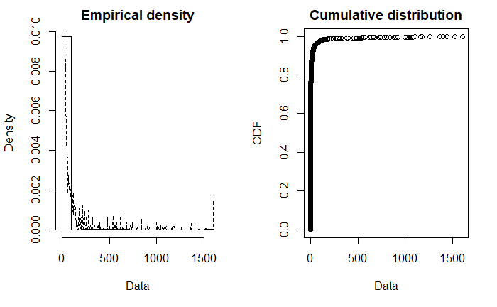

```r
test_dat <- coli_data %>%
  filter(! is.na(ColiVal)) %>%
  select(ColiVal, LCFlag, RCFlag)
plotdist(test_dat$ColiVal, histo = TRUE, demp = TRUE)
```

The package contains and interesting function that provides a graphical representation of data in terms of kurtosis and skewness. The output is helpful for evaluating potential alternative data distributions.

[output not shown]

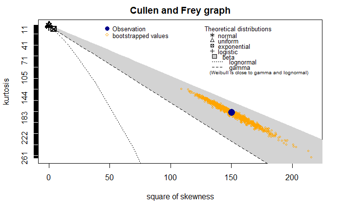

```r
descdist(test_dat$ColiVal, boot = 1000)
```

[output not shown]

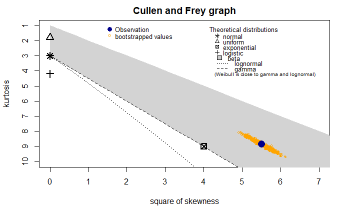

```r
descdist(log10(test_dat$ColiVal), boot = 1000)
```

even log-transformed data is problematic to model. It is significantly more skew than an exponential distribution.

## Fit a Pareto Distribution

The Pareto distribution is not part of base R, but it is included in at least three packages, actuar, EnvStats and VGAM. The internal implementations are slightly different.